# Mise en qualité du Référentiel des Obstacles à l’Ecoulement (ROE) et de la Base de Donnée sur les Obstacles à l’Ecoulement (BDOE)

Présentation du projet Qgis de Mise en qualité de la BDROE

Josselin BARRY

septembre 03, 2025

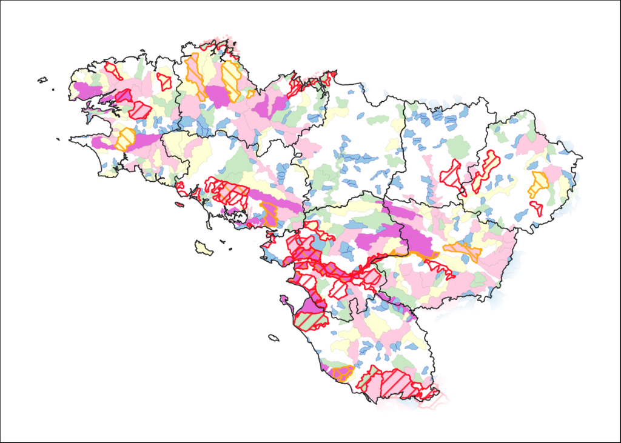

**Avertissement préalable sur la version de Qgis :**

Ce projet a été réalisé avec une version 3.34 de Qgis. Il est recommandé, pour une utilisation optimale de ce projet (affichage des étiquettes notamment), de **le consulter avec une version supérieure ou égale à 3.34. de Qgis**.

# 1 Le groupe de données “Mise en qualité ROE-BDOE” : pour cibler les ouvrages présentant des lacunes attributaires essentielles

## 1.1 La couche BDROE

### 1.1.1 Représentation graphique de la couche BDROE

L’analyse proposée repose sur la couche **BDROE_interne_BZH_PDL_20250727**.

Cette couche géographique est issue d’une jointure entre les couches :

- **ROE** : Référentiel des Obstacles à l’Ecoulement, extraction des données **internes** réalisée le 27 Juillet 2025.
- **BDOE** : Base de Donnée sur les Obstacles à l’Ecoulement, export des données **internes** réalisée le 30 Juillet 2025.

**Sont ensuite écartés, par filtre, les ouvrages gelés ou dont le dérasement peut être considéré comme “soldé”** :

- dont le statut est gelé ;
- dont l’état est entièrement détruit (ou dérasé dans la BDOE) **ET** :
  - dont la hauteur de chute est nulle
  - **OU** dont l’Avis Technique Global est positif (ou éventuellement indéterminé). Ils sont alors considérés comme “soldés” et ne sont donc pas priorisés).

Cette couche est visualisée selon un ensemble de règles afin de pouvoir cibler les lacunes du ROE. Chaque ouvrage peut donc apparaitre dans différentes catégories :

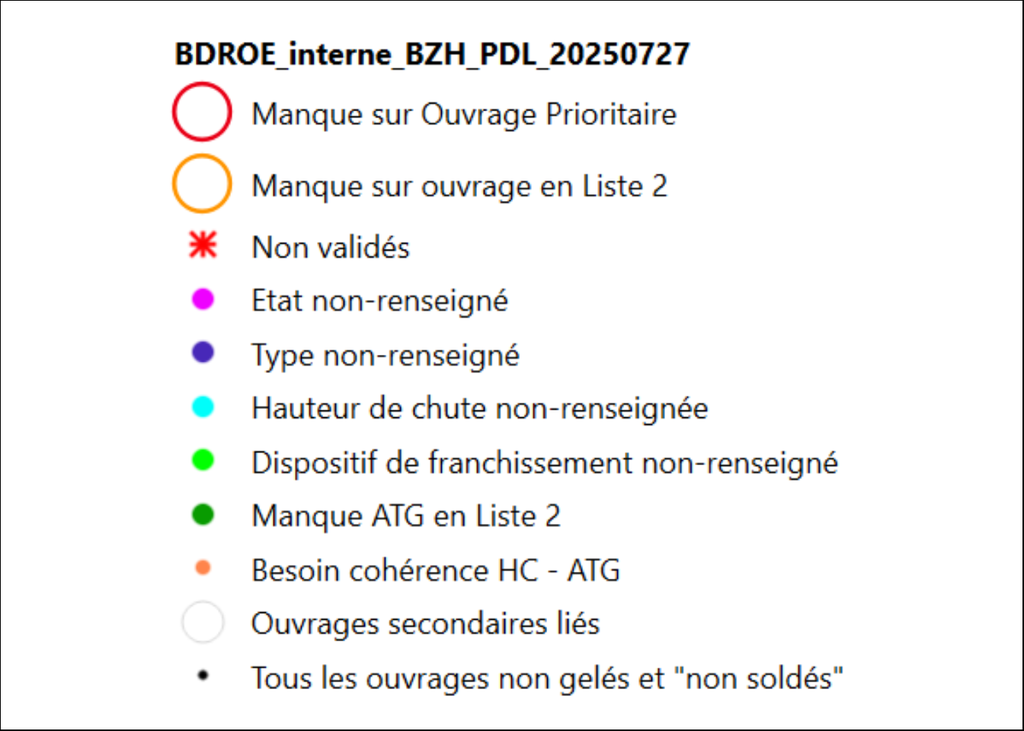

**Manque sur ouvrage prioritaire (hors ATG)** : l’un des manques ciblés (statut, état, type, hauteur de chute ou dispositif de franchissement piscicole, hors “Avis technique Global”) concerne un ouvrage dit “Prioritaire”. Un ouvrage prioritaire doit être renseigné comme tel dans Geobs

**Manque en Liste 2 (hors ATG)** : l’un des manques ciblés (statut, état, type, hauteur de chute ou dispositif de franchissement piscicole, hors ATG) concerne un ouvrage situé en Liste 2 du L214-17.

**Non-validés** : ouvrages dont le “Statut” est ‘non-validé’ dans le ROE (généralement crée par un partenaire)

**Pas d’état** : ouvrages ne disposant pas de l’information “Etat” (Existant, En projet, En construction, Détruit entièrement ou Détruit partiellement), dans le ROE.

**Pas de type** : ouvrages ne disposant pas de l’information “Type” (Barrage, Digue, Epis en rivière, Grille de pisciculture, Obstacle induit par un pont ou Seuil en rivière), dans le ROE.

**Hauteur de chute non renseignée** : ouvrages ne disposant pas de l’information “Hauteur de chute”, ni dans le ROE (classe ou valeur), ni dans la BDOE (valeur), ni dans ICE (valeur). Privilégier le remplissage de la BDOE qui permet d’indiquer une date et un opérateur.

**Dispositif de franchissement non renseigné** : ouvrages ne disposant pas de l’information “Dispositif de franchissement piscicole”, ni dans le ROE, ni dans BDOE.

**Besoin mise en cohérence dérasement - HC – ATG** : ouvrages indiqués comme dérasés ou entièrement détruits, mais dont la hauteur de chute est non nulle et dont l’Avis technique Global (ATG) n’est pas positif (ou indéterminé).

**ATG non renseigné en L2** : ouvrage situé en Liste 2 ne disposant pas de l’information “Avis technique Global”, dans la BDOE.

**Ouvrage secondaire liés** : indique les ouvrages secondaires qui sont liés à un ouvrage principal.

### 1.1.2 Etiquettage de la couche BDROE

Il est possible d’afficher les principales informations rattachées à un ouvrage sous forme d’étiquette en zoomant dessus au-delà d’une échelle de 1/30000éme :

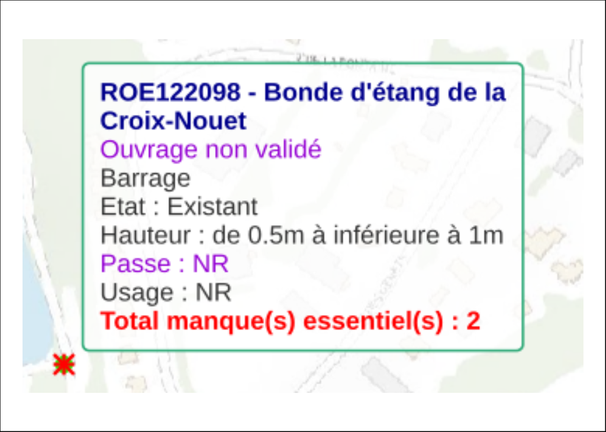

- **Code ROE et nom** de l’ouvrage
- Indique si l’ouvrage est **non validé**
- **Type** d’ouvrage
- **Etat** de l’ouvrage
- **Hauteur de chute** de l’ouvrage
- **Dispositif de franchissement piscicole** de l’ouvrage
- **Usage** associé à l’ouvrage
- **Synthèse du nombre de manques attributaires essentiels** de l’ouvrage (parmis le statut, l’état, le type, la hauteur de chute et le dispositif de franchissement piscicole).

## 1.2 La couche de synthèse des manques de complétude essentiels par bassin versant des masses d’eau

Cette couche est issue d’une analyse des manques de complétude de la couche BDROE et permet de **visualiser les résultats à l’échelle du bassin versant des masses d’eau** selon la représentation graphique suivante :

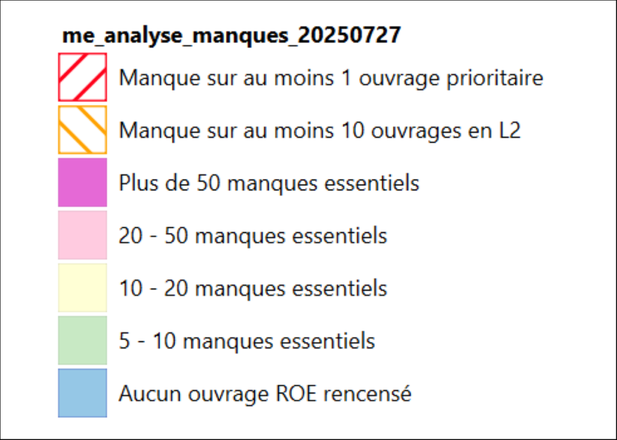

**Manque sur au moins un ouvrage priotaire** : le bassin versant de la masse d’eau comporte au moins un ouvrage prioritaire, dont au moins l’une de ses données essentielles n’est pas renseignée.

**Manque sur au moins 10 ouvrages en L2** : le bassin versant de la masse d’eau comporte au moins 10 ouvrages situés sur un tronçon classé à la liste 2 du L214.17, dont au moins l’une de leurs données essentielles ne sont pas renseignées.

**Manques essentiels** : indique le nombre de manques de complétudes essentiels relevés pour l’ensemble des ouvrages situés sur le bassin versant de la masse d’eau.

**Aucun ouvrage ROE recensé** : le bassin versant de la masse d’eau ne comporte aucun obstacle à l’écoulement enregistré dans le ROE.

# 2 Le groupe de données “Résultats” : pour consulter les données issues du ROE et de la BDOE

## 2.1 Représentation graphique de la couche BDROE

L’analyse proposée repose sur la couche **BDROE_interne_BZH_PDL_20250727** précedemment évoquée, sans écarter les ouvrages gelés ou dérasés.

Cette couche est visualisée selon un ensemble de règles afin de pouvoir consulter les analyse de franchissabilité contenues dans le ROE et la BDOE. Chaque ouvrage peut donc apparaitre dans différentes catégories :

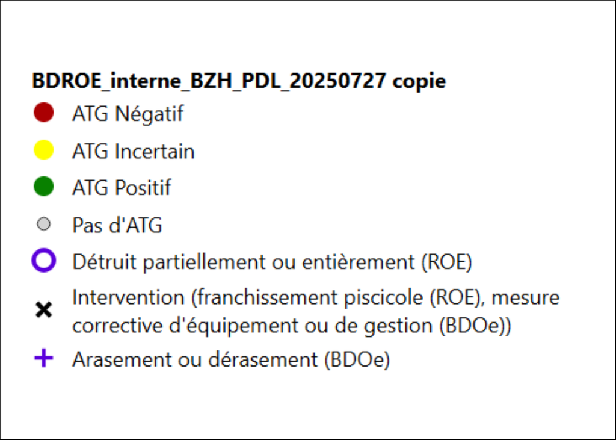

**ATG positif** : Avis Technique Global (ATG) de franchissabilité de la BDOE jugé “positif”. Cet avis doit être formulé pour les ouvrages situés en Liste 2 (L214.17), il prendra alors en considération les espèces cibles du tronçon de cours d’eau de liste 2 auquel il se rattache.

**ATG négatif** : Avis Technique Global (ATG) de franchissabilité de la BDOE jugé “négatif”.

**ATG incertain** : Avis Technique Global (ATG) de franchissabilité de la BDOE jugé “incertain”.

**Pas d’ATG** : aucun Avis Technique Global (ATG) de franchissabilité n’a été saisi dans la BDOE.

**Détruit partiellement ou entièrement** : indique si l’état de l’ouvrage a été qualifié de “partiellement détruit” ou “totalement détruit” dans le ROE.

**Intervention** : indique si l’ouvrage à fait l’objet d’une intervention : amménagement d’un dispositif de franchissement piscicole renseigné dans le ROE ou mesure de gestion ou d’équipement renseignées dans la BDOE.

## 2.2 Représentation graphique des indicateurs linéaires

Trois indicateurs de continuité sont calculés à partir de ces données ROE et BDOE :

Chacun de ces indicateur est calculé à partir de 3 linéaires hydrographiques :

- Drains principaux des masses d’eau,
- Réseau Hydrographique Théorique (RHT)
- Tronçons SYRAH-CE (utilisés dans le cadre de rapportages ou de l’Etat Des Lieux (EDL).

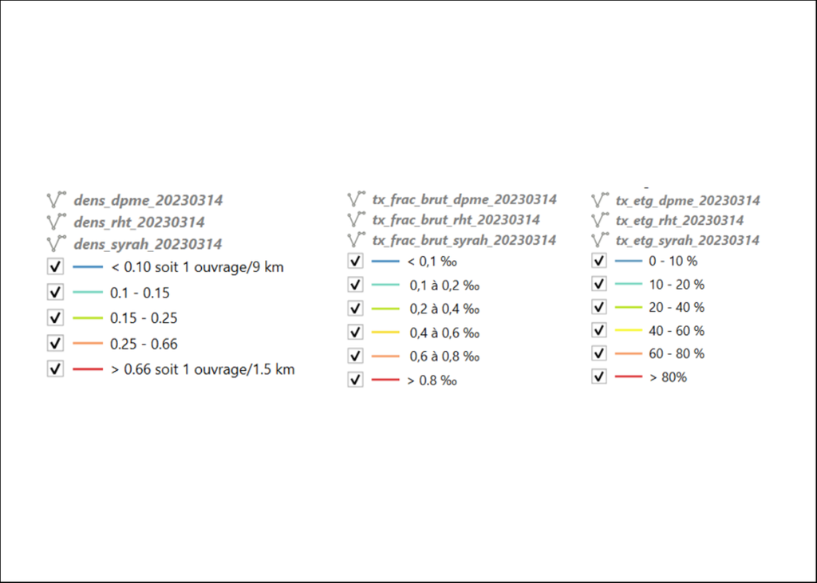

# 3 Le groupe de données “Contexte” : pour contextualiser l’ouvrage dans son environnement réglementaire

Ce groupe de couches contient les données suivantes :

- Les tronçons de cours d’eau inscrits à la **Liste 1 de l’art. L214.17** du CE
- Les tronçons de cours d’eau inscrits à la **Liste 2 de l’art. L214.17** du CE
- Les **Zones d’Action Prioritaire Anguille** (ZAP)
- Les **Schémas d’Aménagement et de Gestion de l’Eau** (SAGE)

# 4 Le groupe de données “Fonds de carte” : pour contextualiser l’ouvrage dans son environnement territorial

**BD Topo Hydrographie** : propose une compilation de différentes couches de la BD Topage (tronçons hydrographiques, surfaces en eau et limites terre-mer) et une représentation graphique élaborée (flux IGN, nécessite d’être connecté). Pour des raisons d’affichage, sa visibilité est limitée à des zoom au delà d’une échelle au 1/30000ème.

**Cartes IGN** : propose une compilation des différents Scan de l’IGN qui s’adaptent automatiquement en fonction de l’échelle de zoom (flux IGN, nécessite d’être connecté)

**Scan 25 Topographique** : Scan 25 de l’IGN (flux IGN, nécessite d’être connecté)

**Photographie aérienne** : BD Ortho 20cm de l’IGN (flux IGN, nécessite d’être connecté)

# 5 Sources

Ce travail est réalisé à partir des logiciels R (partie analytique) et Qgis (partie cartographique).

Les scripts utilisés sont librement accessibles et réutilisables, dans la partie analytique, pour plus d’information consulter le [document de présentation de ce projet sur Github](https://github.com/josselinbarry/geobs).